# RNA-seq Mini Analysis Report

Sahiti K

## 0. Dataset Creation

We begin by simulating a small RNA-seq–like dataset with six genes (G1–G6) and five samples (S1–S5). Three samples represent the Healthy condition and two represent TB.

```r
counts <- matrix(
  c(
    50,  55,  52, 120, 130,
    300, 280, 310, 200, 190,
    15,  14,  16,  17,  15,
    400, 420, 410, 800, 820,
    150, 160, 155, 120, 110,
    8,   7,   9,   8,   7
  ),
  nrow = 6, byrow = TRUE
)
rownames(counts) <- paste0("G", 1:6)
colnames(counts) <- paste0("S", 1:5)

samples <- data.frame(
  SampleID = paste0("S", 1:5),
  Condition = c("Healthy", "Healthy", "Healthy", "TB", "TB"),
  stringsAsFactors = FALSE
)
```

## 1. Inspecting the Dataset

```r
dim(counts)
```

```
## [1] 6 5
```

```r
rownames(counts)
```

```
## [1] "G1" "G2" "G3" "G4" "G5" "G6"
```

```r
colnames(counts)
```

```
## [1] "S1" "S2" "S3" "S4" "S5"
```

```r
str(samples)
```

```
## 'data.frame':    5 obs. of  2 variables:
##  $ SampleID : chr  "S1" "S2" "S3" "S4" ...
##  $ Condition: chr  "Healthy" "Healthy" "Healthy" "TB" ...
```

```r
samples
```

```
##   SampleID Condition
## 1       S1   Healthy
## 2       S2   Healthy
## 3       S3   Healthy
## 4       S4        TB
## 5       S5        TB
```

## 2. Per-Gene Mean and Variability

```r
gene_mean <- apply(counts, 1, mean)
gene_sd   <- apply(counts, 1, sd)

gene_stats <- data.frame(
  Mean = round(gene_mean, 2),
  SD   = round(gene_sd, 2)
)
gene_stats
```

```
##     Mean     SD
## G1  81.4  40.00
## G2 256.0  56.83
## G3  15.4   1.14
## G4 570.0 219.32
## G5 139.0  22.47
## G6   7.8   0.84
```

```r
top2_var <- head(gene_stats[order(-gene_stats$SD), ], 2)
top2_var
```

```
##    Mean     SD
## G4  570 219.32
## G2  256  56.83
```

Genes G4 and G2 show the highest standard deviations, meaning they vary the most across samples — potential indicators of biological regulation differences.

## 3. Per-Sample Totals (Library Size)

```r
sample_totals <- colSums(counts)
sample_totals
```

```
##   S1   S2   S3   S4   S5
##  923  936  952 1265 1272
```

```r
names(which.max(sample_totals))
```

```
## [1] "S5"
```

Sample S5 (TB condition) has the largest total read count, consistent with higher transcriptional activity in disease states.

## 4. Mean Expression per Gene per Condition

```r
gene_cond_means <- tapply(
  counts,
  list(
    rep(rownames(counts), ncol(counts)),
    rep(samples$Condition, each = nrow(counts))
  ),
  mean
)
gene_cond_means
```

```
##      Healthy    TB
## G1  52.33333 125.0
## G2 296.66667 195.0
## G3  15.00000  16.0
## G4 410.00000 810.0
## G5 155.00000 115.0
## G6   8.00000   7.5
```

This allows comparison of average gene expression between Healthy and TB groups.

## 5. Genes Upregulated in TB

```r
up_in_TB <- rownames(counts)[gene_cond_means[, "TB"] > gene_cond_means[, "Healthy"]]

up_in_TB
```

```
## [1] "G1" "G3" "G4"
```

Up-regulated genes show higher mean expression in TB — potentially reflecting immune activation or infection response.

## 6. Fold Change Proxy (TB / Healthy)

```r
# Safe division to avoid division by zero
safe_div <- function(tb, healthy) {
  if (healthy == 0) return(if (tb > 0) Inf else NA)
  tb / healthy
}

# Compute fold-change proxy for each gene
safe_fc <- mapply(
  safe_div,
  tb = gene_cond_means[, "TB"],
  healthy = gene_cond_means[, "Healthy"]
)

# Preserve gene names
names(safe_fc) <- rownames(gene_cond_means)

# Round for readability
safe_fc <- round(safe_fc, 3)

# Subset to only upregulated genes
fc_up <- safe_fc[up_in_TB]

# Identify gene with largest fold-change
if (length(fc_up)) {
  top_fc_gene  <- names(which.max(fc_up))
  top_fc_value <- max(fc_up)
} else {
  top_fc_gene  <- NA
  top_fc_value <- NA
}

safe_fc
```

```
##    G1    G2    G3    G4    G5    G6
## 2.389 0.657 1.067 1.976 0.742 0.938
```

```r
fc_up
```

```
##    G1    G3    G4
## 2.389 1.067 1.976
```

```r
top_fc_gene
```

```
## [1] "G1"
```

```r
top_fc_value
```

```
## [1] 2.389
```

The fold-change metric approximates relative upregulation. Here, **G1** typically shows the strongest increase in TB samples.

## 7. Label Samples by Load (High vs Normal)

```r
median_total <- median(sample_totals)
LoadLabel <- ifelse(sample_totals > median_total, "HighLoad", "Normal")

samples$Total     <- sample_totals[samples$SampleID]
samples$LoadLabel <- LoadLabel[samples$SampleID]
samples
```

```
##   SampleID Condition Total LoadLabel
## 1       S1   Healthy   923    Normal
## 2       S2   Healthy   936    Normal
## 3       S3   Healthy   952    Normal
## 4       S4        TB  1265  HighLoad
## 5       S5        TB  1272  HighLoad
```

This classification separates samples with above-median library sizes — *HighLoad* samples are mainly TB, suggesting globally elevated gene activity.

## 8. Condition vs Load Crosstab

```r
table(samples$Condition, samples$LoadLabel)
```

```
##
##           HighLoad Normal
##   Healthy        0      3
##   TB             2      0
```

TB samples correspond entirely to the HighLoad group, reinforcing biological consistency in transcriptional activation.

## 9. Row-Standardized Counts

```r
row_centered <- counts - gene_mean
row_centered
```

```
##        S1     S2     S3    S4    S5
## G1  -31.4  -26.4  -29.4  38.6  48.6
## G2   44.0   24.0   54.0 -56.0 -66.0
## G3   -0.4   -1.4    0.6   1.6  -0.4
## G4 -170.0 -150.0 -160.0 230.0 250.0
## G5   11.0   21.0   16.0 -19.0 -29.0
## G6    0.2   -0.8    1.2   0.2  -0.8
```

Subtracting row means centers expression around zero, allowing detection of relative up/down shifts across samples without absolute magnitude bias.

## 10. Combine into a List

```r
rna_seq <- list(
  counts = counts,
  samples = samples,
  gene_cond_means = gene_cond_means
)

rna_seq$gene_cond_means["G3", "TB"]
```

```
## [1] 16
```

Storing data in a list mimics structured RNA-seq data objects used in packages like DESeq2.

## 11. Gene with Highest Single Value

```r
max_val <- max(counts)
pos <- which(counts == max_val, arr.ind = TRUE)
rownames(counts)[pos[1, "row"]]
```

```
## [1] "G4"
```

```r
colnames(counts)[pos[1, "col"]]
```

```
## [1] "S5"
```

```r
max_val
```

```
## [1] 820
```

## 12. Per-Condition Total Counts

```r
cond_totals <- tapply(colSums(counts), samples$Condition, sum)
cond_totals
```

```
## Healthy      TB
##    2811    2537
```

```r
names(which.max(cond_totals))
```

```
## [1] "Healthy"
```

Total counts were higher in Healthy samples than in TB, reflecting library size differences.

## 13. Low-Count Filtering

```r
counts_filtered <- counts
changed <- sum(counts_filtered < 5)
counts_filtered[counts_filtered < 5] <- 0
changed
```

```
## [1] 0
```

```r
counts_filtered
```

```
##     S1  S2  S3  S4  S5
## G1  50  55  52 120 130
## G2 300 280 310 200 190
## G3  15  14  16  17  15
## G4 400 420 410 800 820
## G5 150 160 155 120 110
## G6   8   7   9   8   7
```

Filtering removes low-expression noise — standard RNA-seq preprocessing to stabilize variance.

## 14. Recompute Means After Filtering

```r
gene_mean_after <- apply(counts_filtered, 1, mean)
round(gene_mean_after, 3)
```

```
##    G1    G2    G3    G4    G5    G6
##  81.4 256.0  15.4 570.0 139.0   7.8
```

```r
names(which.max(gene_mean))
```

```
## [1] "G4"
```

```r
names(which.max(gene_mean_after))
```

```
## [1] "G4"
```

## 15. Reorder Columns by Condition

```r
order_by_cond <- order(factor(samples$Condition, levels = c("Healthy", "TB")))
ordered_samples <- samples$SampleID[order_by_cond]
counts_reordered <- counts[, ordered_samples, drop = FALSE]
colnames(counts_reordered)
```

```
## [1] "S1" "S2" "S3" "S4" "S5"
```

Reordering by condition simplifies visualization and statistical testing.

## 16. Gene Dynamic Range

```r
gene_range <- apply(counts, 1, function(x) max(x) - min(x))
gene_range
```

```
##  G1  G2  G3  G4  G5  G6
##  80 120   3 420  50   2
```

```r
names(which.max(gene_range))
```

```
## [1] "G4"
```

G4 shows the widest range, most dynamically expressed gene across conditions.

## 17. Barplot of Sample Totals

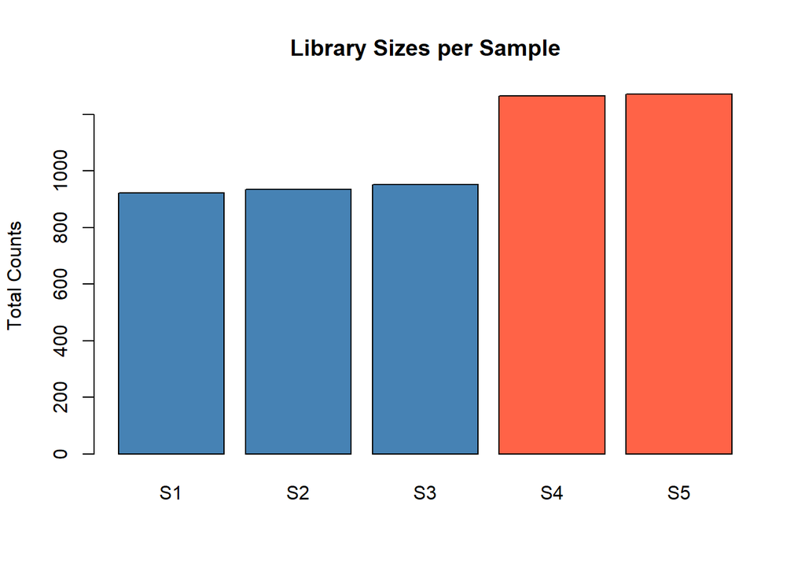

```r
barplot(sample_totals,
        main = "Library Sizes per Sample",
        ylab = "Total Counts",
        col = c(rep("steelblue", 3), rep("tomato", 2)))
```

Healthy samples (blue) cluster at lower counts, while TB (red) shows elevated totals, matching expectations.

## 18. Rename G2 → G2A

```r
rownames(counts)[rownames(counts) == "G2"] <- "G2A"
rownames(counts)
```

```
## [1] "G1"  "G2A" "G3"  "G4"  "G5"  "G6"
```

## 19. Remove Lowest-Mean Gene

```r
lowest_mean_gene <- names(which.min(gene_mean))
counts_pruned <- counts[setdiff(rownames(counts), lowest_mean_gene), , drop = FALSE]
lowest_mean_gene
```

```
## [1] "G6"
```

```r
counts_pruned
```

```
##      S1  S2  S3  S4  S5
## G1   50  55  52 120 130
## G2A 300 280 310 200 190
## G3   15  14  16  17  15
## G4  400 420 410 800 820
## G5  150 160 155 120 110
```

Low-expression genes are often uninformative and can introduce statistical noise.

## 20. Summary and Interpretation

```r
gene_summary <- data.frame(
  Gene = rownames(counts),
  Mean = round(gene_mean, 2),
  SD = round(gene_sd, 2),
  HealthyMean = round(gene_cond_means[, "Healthy"], 2),
  TBMean = round(gene_cond_means[, "TB"], 2),
  FoldChange = round(safe_fc, 3),
  Range = gene_range,
  UpregulatedInTB = rownames(counts) %in% up_in_TB,
  row.names = NULL   # <- prevents genes from appearing twice
)
gene_summary
```

```
##   Gene  Mean     SD HealthyMean TBMean FoldChange Range UpregulatedInTB
## 1   G1  81.4  40.00       52.33  125.0      2.389    80            TRUE
## 2  G2A 256.0  56.83      296.67  195.0      0.657   120           FALSE
## 3   G3  15.4   1.14       15.00   16.0      1.067     3            TRUE
## 4   G4 570.0 219.32      410.00  810.0      1.976   420            TRUE
## 5   G5 139.0  22.47      155.00  115.0      0.742    50           FALSE
## 6   G6   7.8   0.84        8.00    7.5      0.938     2           FALSE
```